# Project Checkpoint

Tej Seth and Projeet Mukherjee

November 5th, 2021

## Project Checkpoint

This project checkpoint is designed for you to begin your data exploration process. Before creating a multiple linear regression model, you should always familiarize yourself with the data set and its individual variables. In this checkpoint, you will create numerical summaries and visualizations that should help guide your modelling process – which explanatory variables will help explain the outcome, which variables need any transformation, which variables may need an interaction, etc.

Most of your data sets have *several* predictors to choose from. In this assignment, I only ask that you analyze a few of them, but **please do not limit yourself to these variables** throughout your final project. Creating your regression model should be an iterative process that uses different analysis techniques to create the best fitting model possible - trying out new variables, examining different transformations, etc.

You all selected a few *potential* explanatory variables of interest in your project proposal. **These do not have to be the variables used here.** You may find that they’re not as helpful in explaining the response as you thought. You are welcome (and encouraged!) to change, adjust, and [pivot](https://www.youtube.com/watch?v=8w3wmQAMoxQ), as needed.

And if you have any questions throughout the process, please ask us! The instructional team is here to help!

### Creating an RStudio Project

Now is a good time to create an RStudio Project (like you did in Lab 6) to keep all of your project documents in one place. To do this, please follow these steps:

1. Open up a *new* session of RStudio
2. Navigate to File > New Project
3. Click on New Directory
4. Click on New Project
5. Give your project a “Directory name” (something like “stats401project”)
6. Decide where you would like the project stored (I keep mine - and all other Stats 401 assignments - in a folder on my computer called stats401)
7. Click “Create Project”
8. Move this “projectCheckpoint.Rmd” document and your data set to the project folder

### Read Data

Once you have created your RStudio Project and moved your data set into the folder, you will then be able to read in your data. To do this, you’ll use the `read.csv()` function and store it for use throughout the file.

Reach out to us if you need help reading in your data!

```r
library(tidyverse)
fifa_22 <- read.csv("players_fifa22.csv")
```

Once you have successfully loaded your data, complete the tasks below to complete the project checkpoint. *Failure to properly follow the instructions will result in point deductions.*

### Variables (2 points)

Fill in the following bullets with the variables you will be analyzing below. I recommend starting with the variables you described in your project proposal, but these can change throughout your modelling process. There is no specific number of variables that your final model has to contain.

- Response: `Overall`
- Quantitative Predictor #1: `Age`
- Quantitative Predictor #2: `ValueEUR`
- Quantitative Predictor #3: `ShootingTotal`
- Categorical Predictor: `BestPosition`

### Numerical Summaries (4 points)

Run the numerical summaries (using `summary()` or other similar functions) for your quantitative variables (response + predictors).

```r
summary(fifa_22$Overall)
```

```
##    Min. 1st Qu.  Median    Mean 3rd Qu.    Max.
##   48.00   62.00   66.00   65.82   70.00   93.00
```

```r
summary(fifa_22$Age)
```

```
##    Min. 1st Qu.  Median    Mean 3rd Qu.    Max.
##   16.00   21.00   25.00   25.18   29.00   54.00
```

```r
summary(fifa_22$ValueEUR)
```

```
##      Min.   1st Qu.    Median      Mean   3rd Qu.      Max.
##         0    475000    975000   2857652   2000000 194000000
```

```r
summary(fifa_22$ShootingTotal)
```

```
##    Min. 1st Qu.  Median    Mean 3rd Qu.    Max.
##   18.00   44.00   56.00   53.54   64.00   94.00
```

What is the mean and range of your *response* variable? This is the variability that you will be trying to explain with your model!

**Answer:** The mean of the response variable is 65.82 and the range is 45 (93-48)

### Histograms (10 points)

Create four histograms for your quantitative variables (response + predictors). *Be sure to give each plot appropriate axis labels and a title.*

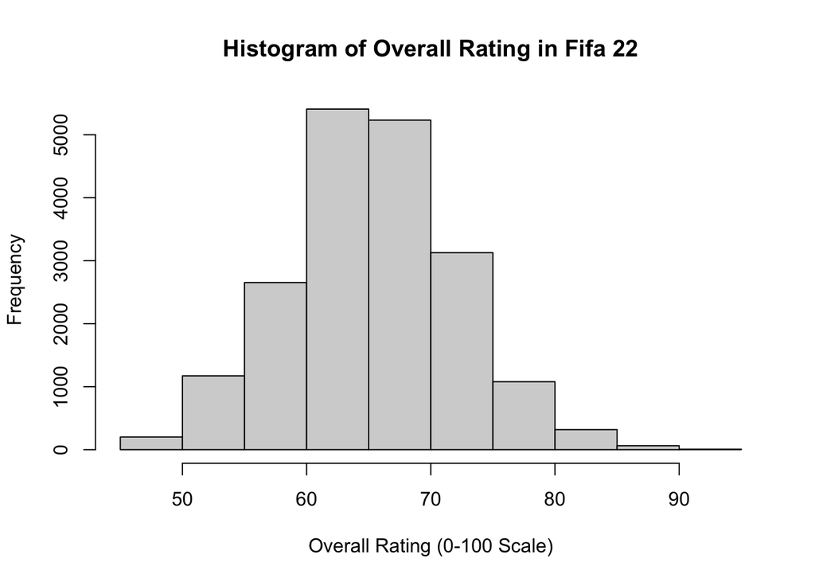

```r
hist(fifa_22$Overall,
     xlab = "Overall Rating (0-100 Scale)",
     main = "Histogram of Overall Rating in Fifa 22")
```

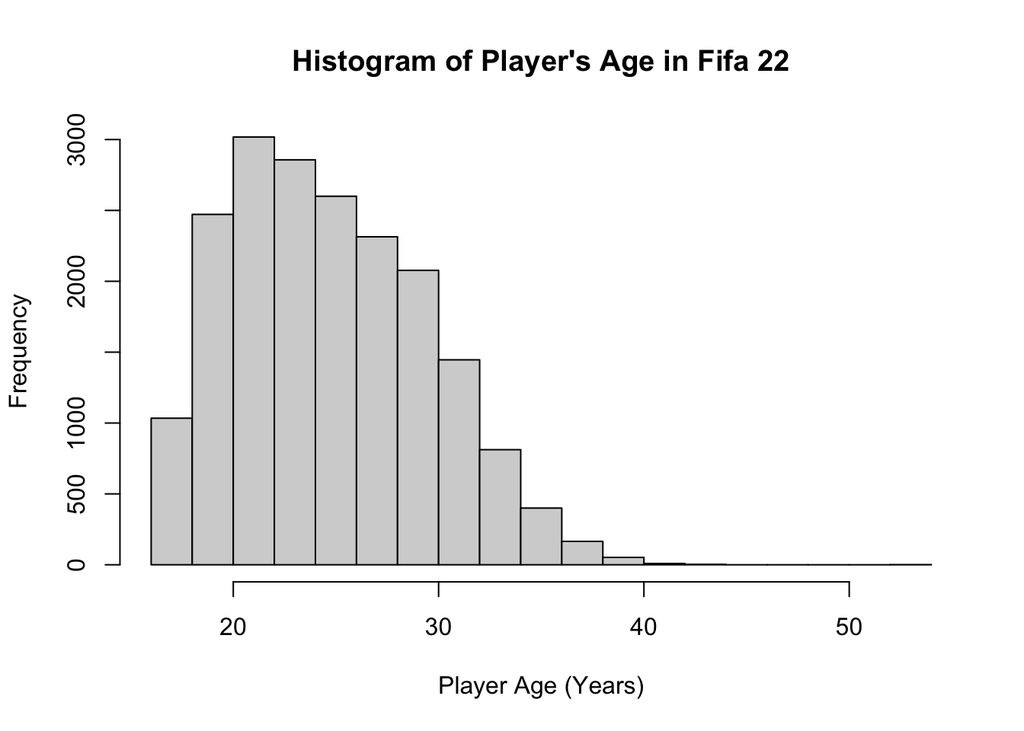

```r
hist(fifa_22$Age,
     xlab = "Player Age (Years)",
     main = "Histogram of Player's Age in Fifa 22")
```

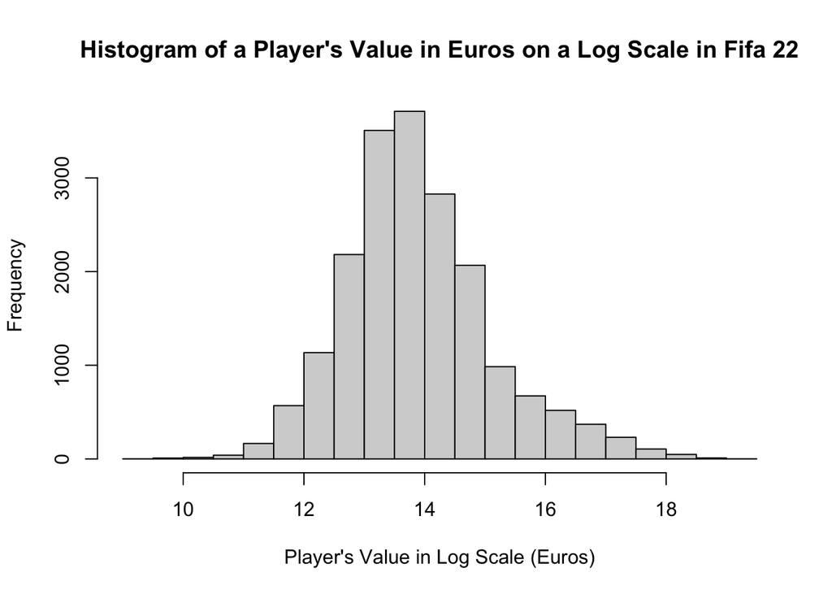

```r
hist(log(fifa_22$ValueEUR),
     xlab = "Player's Value in Log Scale (Euros)",
     main = "Histogram of a Player's Value in Euros on a Log Scale in Fifa 22")
```

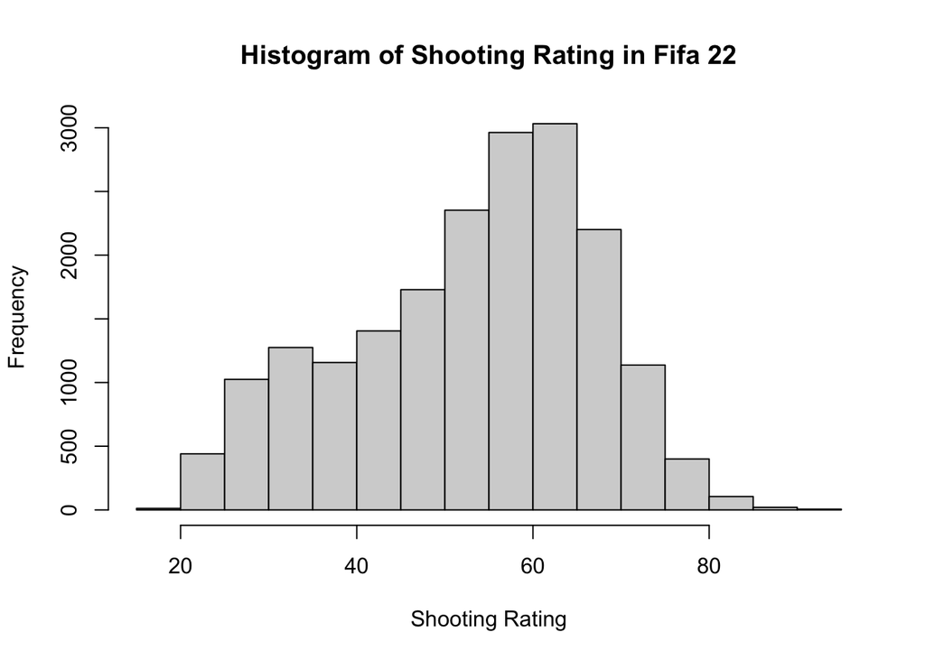

```r
hist(fifa_22$ShootingTotal,
     xlab = "Shooting Rating",
     main = "Histogram of Shooting Rating in Fifa 22")
```

In 2 - 3 sentences, reflect on your histograms. Things to consider: Would any of these quantitative variables benefit from a log transformation? Remember, we are looking for a *heavy* right skew - not just a slight right skew. (I recommend plotting the log-transformed variable to verify that the transformation helps.)

**Answer:** `Overall` rating has a pretty normal distribution with a slight right skew. `Age` has slightly more of a right skew but giving it a right log scale made it uniform which is not what we want. `ValueEUR` did benefit from a log transformation as it fixed its strong right skew.

### Scatterplot Matrix (6 points)

Create a **scatterplot matrix** of your response against the three quantitative predictors. Note: we are not asking for individual scatterplots.

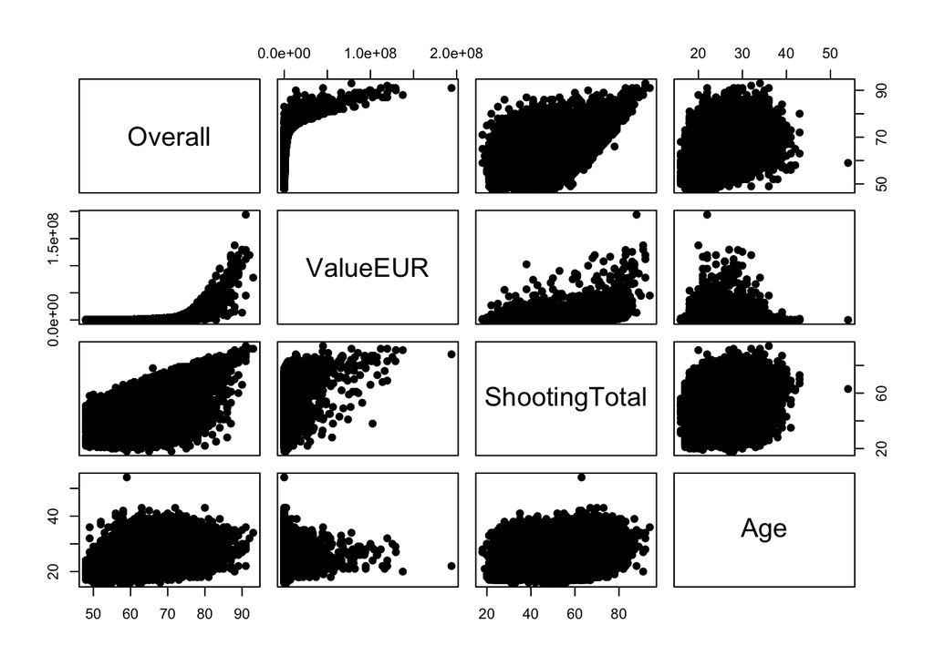

```r
fifa_select <- fifa_22 %>%
  select(Overall, ValueEUR, ShootingTotal, Age)

pairs(fifa_select, pch = 19)
```

In 2 - 3 sentences, reflect on your scatterplot matrix. Things to consider: Do there appear to be any significant linear relationships between any of the predictors and your response variable? Would any of the predictors potentially benefit from adding a quadratic term? Are there any strong relationships between two of the predictor variables?

**Answer:** It’s tough to make out because of all the data points but there seems to be a quadratic linear relationship between `ValueEUR` and `Overall`. There also seems to be a linear relationship between `ShootingTotal` and `Overall`. On top of that, `ValueEUR` and `ShootingTotal` might have a linear relationship that could benefit from adding a quadratic term.

### Boxplot (6 points)

Create a side-by-side boxplot of your response variable versus your categorical predictor. *Be sure to give your plot appropriate axis labels and a title.*

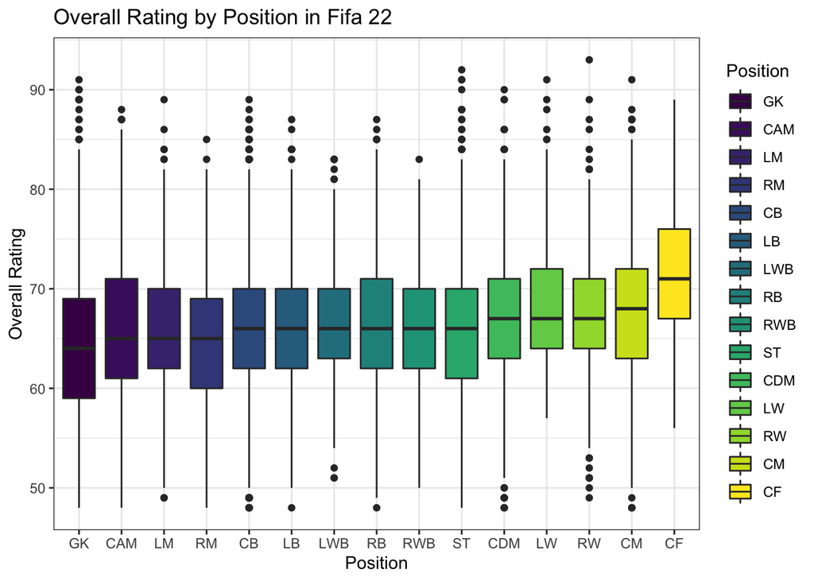

```r
fifa_22 %>%
  group_by(BestPosition) %>%
  mutate(med = median(Overall)) %>%
  ungroup() %>%
  ggplot(aes(x = fct_reorder(BestPosition, med), y = Overall)) +
  geom_boxplot(aes(fill = fct_reorder(BestPosition, med))) +
  scale_fill_viridis_d() +
  theme_bw() +
  labs(x = "Position",
       y = "Overall Rating",
       title = "Overall Rating by Position in Fifa 22",
       fill = "Position")
```

### Conclusions (4 points)

Write 3 - 5 sentences summarizing your initial findings. Highlight any key findings from the above initial data exploration and where you plan to go from here. If you have any questions for the instructional team (about coding, the direction of your analysis, possible transformations, etc.), you can include them here! This doesn’t have to be anything new/profound from what you discovered above.

**Answer:** One of the key findings is that `ValueEUR` is strongly right skewed and will need to be log transformed because of that when we make our model. It also seems like it has might need to have a quadratic opponent the modeling with `Overall`. The response variable being normally distributed is going to be helpful in the modeling process. The next steps from here are to add these variables into the model and see the different interaction terms and then decide if any more variables need to be added from there.